# Forest Fires

RF

2022-08-03

Practicing ggplot with a forest fires dataset. [Source](http://www3.dsi.uminho.pt/pcortez/fires.pdf)

```r
library(tidyverse)
fires <- read_csv("forestfires.csv")
```

Column descriptions: **X**: X-axis spatial coordinate within the Montesinho park map: 1 to 9 **Y**: Y-axis spatial coordinate within the Montesinho park map: 2 to 9 **month**: Month of the year: ‘jan’ to ‘dec’ **day**: Day of the week: ‘mon’ to ‘sun’ **FFMC**: Fine Fuel Moisture Code index from the [fire weather index FWI](https://en.wikipedia.org/wiki/Forest_fire_weather_index) system: 18.7 to 96.20 **DMC**: Duff Moisture Code index from the FWI system: 1.1 to 291.3 **DC**: Drought Code index from the FWI system: 7.9 to 860.6 **ISI**: Initial Spread Index from the FWI system: 0.0 to 56.10 **temp**: Temperature in Celsius degrees: 2.2 to 33.30 **RH**: Relative humidity in percentage: 15.0 to 100 **wind**: Wind speed in km/h: 0.40 to 9.40 **rain**: Outside rain in mm/m2 : 0.0 to 6.4 **area**: The burned area of the forest (in ha): 0.00 to 1090.84

```r
spec(fires)
unique(fires$month)
```

```
##  [1] "mar" "oct" "aug" "sep" "apr" "jun" "jul" "feb" "jan" "dec" "may" "nov"
```

```r
unique(fires$day)
```

```
## [1] "fri" "tue" "sat" "sun" "mon" "wed" "thu"
```

Convert month and day to categorical variables with the correct orders.

```r
month_order <- c('jan', 'feb', 'mar', 'apr', 'may', 'jun', 'jul', 'aug', 'sep', 'oct', 'nov', 'dec')
day_order <- c('mon','tue','wed','thu','fri','sat','sun')
fires <- fires %>%
  mutate(
    month = factor(month, levels = month_order),
    day = factor(day, levels = day_order)
  )
```

Count number of forest fires by month.

```r
fires_month <- fires %>%
  group_by(month) %>%
  summarise(month_count =n())
fires_month
```

```
## # A tibble: 12 × 2
##    month month_count
##    <fct>       <int>
##  1 jan             2
##  2 feb            20
##  3 mar            54
##  4 apr             9
##  5 may             2
##  6 jun            17
##  7 jul            32
##  8 aug           184
##  9 sep           172
## 10 oct            15
## 11 nov             1
## 12 dec             9
```

Count number of forest fires by day of the week.

```r
fires_day <- fires %>%
  group_by(day) %>%
  summarise(day_count = n())
fires_day
```

```
## # A tibble: 7 × 2
##   day   day_count
##   <fct>     <int>
## 1 mon          74
## 2 tue          64
## 3 wed          54
## 4 thu          61
## 5 fri          85
## 6 sat          84
## 7 sun          95
```

Visualize the fires_month tibble.

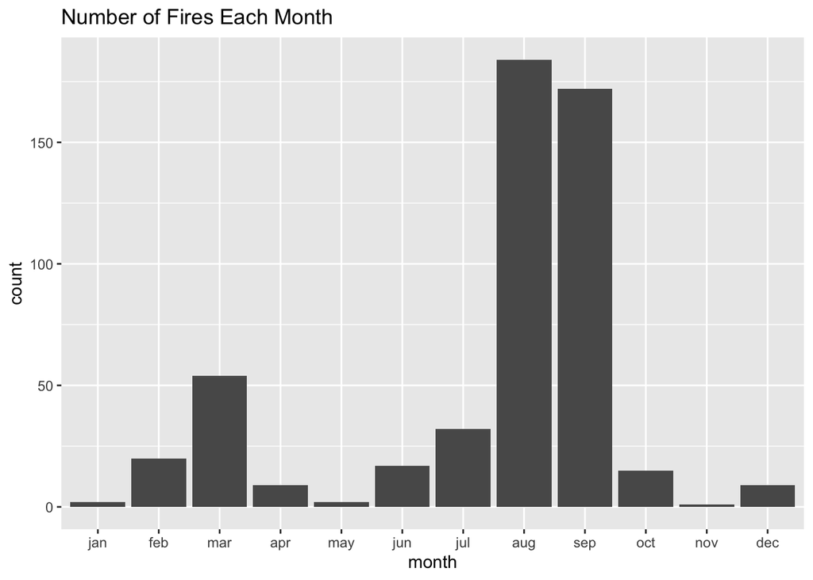

```r
fires_month %>%
  ggplot(aes(x=month, y=month_count)) +
  geom_col() +
  labs(
    title = "Number of Fires Each Month",
    y = "count"
  )
```

Visualize the fires_day tibble.

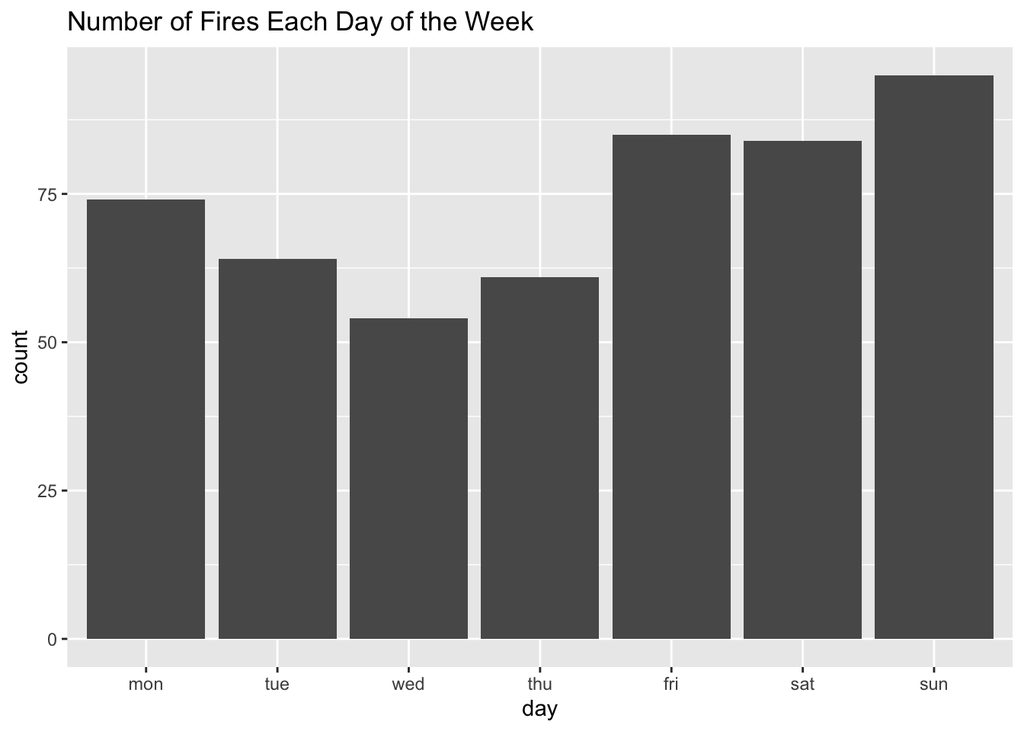

```r
fires_day %>%
  ggplot(aes(x=day, y=day_count)) +
  geom_col() +
  labs(
    title = "Number of Fires Each Day of the Week",
    y = "count"
  )
```

August and September have the most fires, as well as weekends. Let’s look at the relationship between the other columns and month.

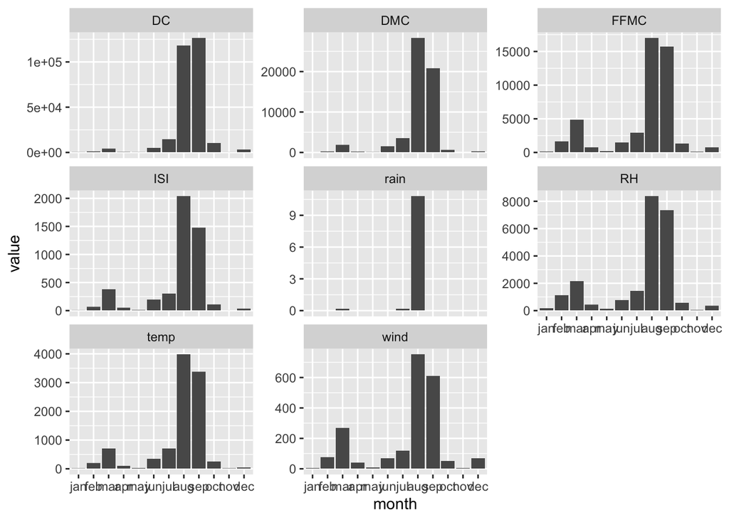

```r
fires_long <- fires %>%
  pivot_longer(
    cols = c(FFMC, DMC, DC, ISI, temp, RH, wind, rain),
    names_to = "data_col",
    values_to = "value"
  )
fires_long %>%
  ggplot(aes(x=month, y=value)) +
  geom_col() +
  facet_wrap(vars(data_col), scales = "free_y")
```

All of the variables have increased values in August, and all but rain have increased values in September.

Let’s look at the relationship these variables have to the area burned by a fire.

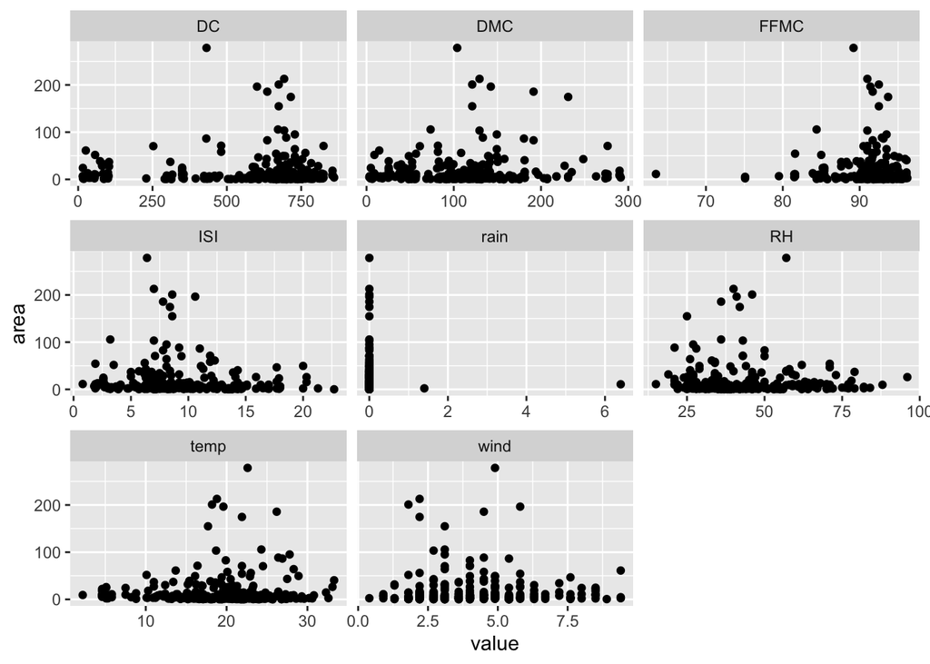

```r
fires_long %>%
  filter(area < 300 & area > 0) %>%
  ggplot(aes(x=value, y=area)) +
  geom_point() +
  facet_wrap(vars(data_col), scales = "free_x") +
  labs(
    y="area"
  )
```